# IODS course project

Ville Tanskanen

# Introduction to Open Data Science - Course Project

# About the project

This is a course diary for the UH course *Introduction to Open Data Science*. I was introduced to this course by our PhD-program’s advisor and it will be included as a course in my *transferrable studies* quota (10 credits).

The link for this diary is: https://villetan.github.io/IODS-project/

```r
# This is a so-called "R chunk" where you can write R code.

date()
```

```
## [1] "Fri Nov 19 16:11:04 2021"
```

# Linear Regression

*Describe the work you have done this week and summarize your learning.*

- Describe your work and results clearly.
- Assume the reader has an introductory course level understanding of writing and reading R code as well as statistical methods.
- Assume the reader has no previous knowledge of your data or the more advanced methods you are using.

```r
setwd("~/Koulu/IODS-project")
date()
```

```
## [1] "Fri Nov 19 16:11:04 2021"
```

Lets read the data in from local file…

```r
data = read.csv("data/wk2data.csv")
```

… and see the summary of it.

```r
summary(data)
```

```
##     gender               Age           Attitude         Points
##  Length:166         Min.   :17.00   Min.   :14.00   Min.   : 7.00
##  Class :character   1st Qu.:21.00   1st Qu.:26.00   1st Qu.:19.00
##  Mode  :character   Median :22.00   Median :32.00   Median :23.00
##                     Mean   :25.51   Mean   :31.43   Mean   :22.72
##                     3rd Qu.:27.00   3rd Qu.:37.00   3rd Qu.:27.75
##                     Max.   :55.00   Max.   :50.00   Max.   :33.00
##       deep            stra            surf
##  Min.   :1.583   Min.   :1.250   Min.   :1.583
##  1st Qu.:3.333   1st Qu.:2.625   1st Qu.:2.417
##  Median :3.667   Median :3.188   Median :2.833
##  Mean   :3.680   Mean   :3.121   Mean   :2.787
##  3rd Qu.:4.083   3rd Qu.:3.625   3rd Qu.:3.167
##  Max.   :4.917   Max.   :5.000   Max.   :4.333
```

Let’s also plot a graphical summary.

```r
library(GGally)
```

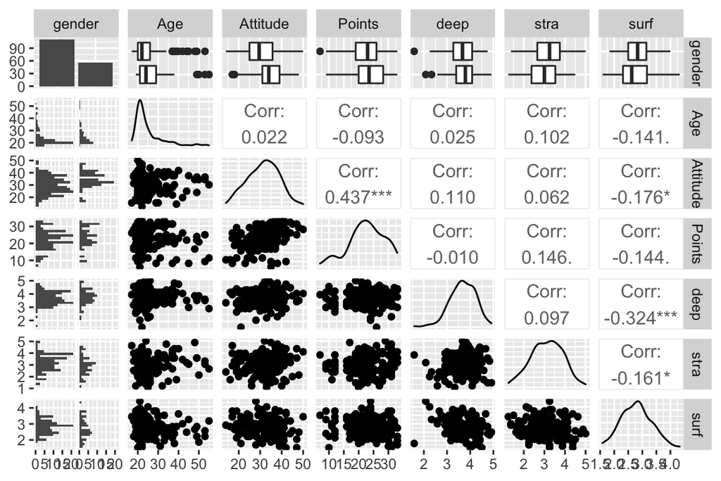

```r
library(ggplot2)
p <- ggpairs(data, mapping = aes(), lower = list(combo = wrap("facethist", bins = 20)))
p
```

First, lets look at the distributions of the variables individually. There are more females present in the data set. The ages of the subjects are right skewed, so that people in their 20’s are more prevalent. Points have a small spike in presence of low points, but other than that it is near Gaussian in the region above 15 points. Other variables seem to be balanced rather well over their domain.

Next, lets fit a regression model with three variables and print the summary.

```r
lm_fit = lm("Points ~ Attitude + deep + stra", data = data)
summary(lm_fit)
```

```
##
## Call:
## lm(formula = "Points ~ Attitude + deep + stra", data = data)
##
## Residuals:
##      Min       1Q   Median       3Q      Max
## -17.5239  -3.4276   0.5474   3.8220  11.5112
##
## Coefficients:
##             Estimate Std. Error t value Pr(>|t|)
## (Intercept) 11.39145    3.40775   3.343  0.00103 **
## Attitude     0.35254    0.05683   6.203 4.44e-09 ***
## deep        -0.74920    0.75066  -0.998  0.31974
## stra         0.96208    0.53668   1.793  0.07489 .
## ---
## Signif. codes:  0 '***' 0.001 '**' 0.01 '*' 0.05 '.' 0.1 ' ' 1
##
## Residual standard error: 5.289 on 162 degrees of freedom
## Multiple R-squared:  0.2097, Adjusted R-squared:  0.195
## F-statistic: 14.33 on 3 and 162 DF,  p-value: 2.521e-08
```

It seems that the attitude is the only statistically significant feature explaining good (or bad) points in the course. What this means in laymen terms is that the coefficients for the deep and stra might as well have been 0 and thus they would have not contributed to the score itself.

Lets remove stra and deep since they are non-significant, we’ll also keep the Intercept therm as it showed significance as well.

```r
lm_fit_ = lm("Points ~ Attitude", data = data)
summary(lm_fit_)
```

```
##
## Call:
## lm(formula = "Points ~ Attitude", data = data)
##
## Residuals:
##      Min       1Q   Median       3Q      Max
## -16.9763  -3.2119   0.4339   4.1534  10.6645
##
## Coefficients:
##             Estimate Std. Error t value Pr(>|t|)
## (Intercept) 11.63715    1.83035   6.358 1.95e-09 ***
## Attitude     0.35255    0.05674   6.214 4.12e-09 ***
## ---
## Signif. codes:  0 '***' 0.001 '**' 0.01 '*' 0.05 '.' 0.1 ' ' 1
##
## Residual standard error: 5.32 on 164 degrees of freedom
## Multiple R-squared:  0.1906, Adjusted R-squared:  0.1856
## F-statistic: 38.61 on 1 and 164 DF,  p-value: 4.119e-09
```

Now, they both are significant with p-values effectively zero. This means that we can be pretty certain that the coefficient estimates are not zeros.

The relationship between Attitude and Points is clear positive trend as seen on the plot below. There the regression line found is plotted with black solid line.

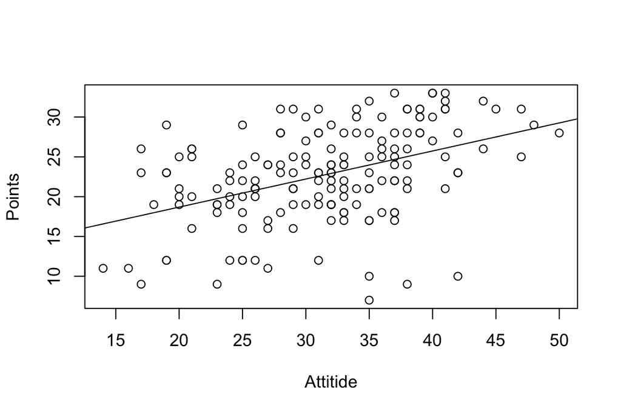

```r
plot(data$Attitude, data$Points, xlab = "Attitide", ylab="Points")
abline(a=lm_fit_$coefficients["(Intercept)"], b=lm_fit_$coefficients["Attitude"])
```

The multiple R-squared is the proportion of variance explained by the linear model. So the linear model explains about 20% of the variance in the response variable, that is, points. The rest of the 80% of the variance seem to be inherent to the data.

Lets plot Residuals vs. fitted values, normal QQ-plot and residual vs. leverage.

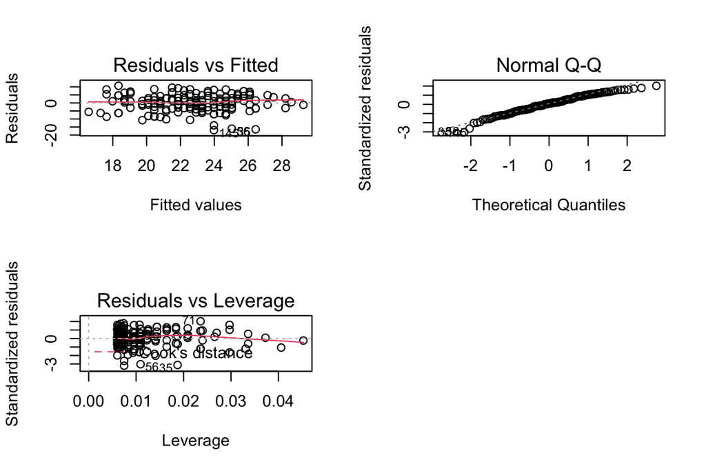

```r
par(mfrow=c(2,2))
plot(lm_fit_, which = c(1,2,5))
```

The interpretation of “Residuals vs. fitted” is that one can see where the linear model makes mistakes. For example if there is non-linearity, then it is expected to be visible in this plot. The closer to the zero line the residuals are, the better the model. A perfect model would have a straight line at 0. In our model there is no pattern of nonlinearity as the points are uniformly distributed across different locations of x-axis.

The second plot, the QQ-plot, estimates if the errors of the model are really normally distributed, which is an assumption of the linear model. Since the QQ-plot is not completely straight, there are slight evidence, that the residuals are not Normal, but rather left skewed. See the plot below. However, the skew is very minor.

The third plot, Residuals vs. leverage, studies if a single (or a group) data point is responsible for the “fit” more than the others. It seems that no single data point is affecting the fit significantly more than others.

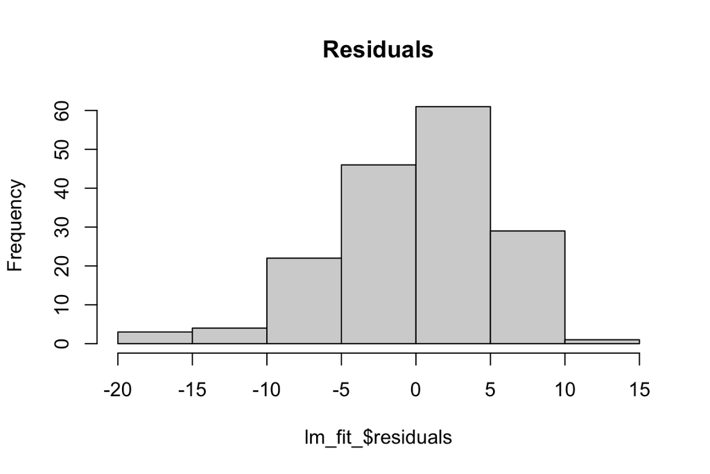

```r
hist(lm_fit_$residuals, main="Residuals")
```

# Logistic Regression

Lets read the data we generated using create_alc.R script and see that it looks ok.

```r
alc_data = read.csv("data/alc_data.csv")
print(dim(alc_data))
```

```
## [1] 370  35
```

```r
str(alc_data)
```

```
## 'data.frame':    370 obs. of  35 variables:
##  $ school    : chr  "GP" "GP" "GP" "GP" ...
##  $ sex       : chr  "F" "F" "F" "F" ...
##  $ age       : int  15 15 15 15 15 15 15 15 15 15 ...
##  $ address   : chr  "R" "R" "R" "R" ...
##  $ famsize   : chr  "GT3" "GT3" "GT3" "GT3" ...
##  $ Pstatus   : chr  "T" "T" "T" "T" ...
##  $ Medu      : int  1 1 2 2 3 3 3 2 3 3 ...
##  $ Fedu      : int  1 1 2 4 3 4 4 2 1 3 ...
##  $ Mjob      : chr  "at_home" "other" "at_home" "services" ...
##  $ Fjob      : chr  "other" "other" "other" "health" ...
##  $ reason    : chr  "home" "reputation" "reputation" "course" ...
##  $ guardian  : chr  "mother" "mother" "mother" "mother" ...
##  $ traveltime: int  2 1 1 1 2 1 2 2 2 1 ...
##  $ studytime : int  4 2 1 3 3 3 3 2 4 4 ...
```

[output cut: 21 more lines]

Let us select 4 interesting variables to seek the relationship with the alcohol consumption.

```r
interesting_cols = c("freetime", "romantic", "address", "famrel")
```

The hypothesis is that these variables correlate with alieness to the society, which in turn, I speculate, affects the alcohol consumption. I speculate that freetime and ruralness correlate with alcohol consumption positively, while being in a romantic relationship and having good family relations correlate negatively.

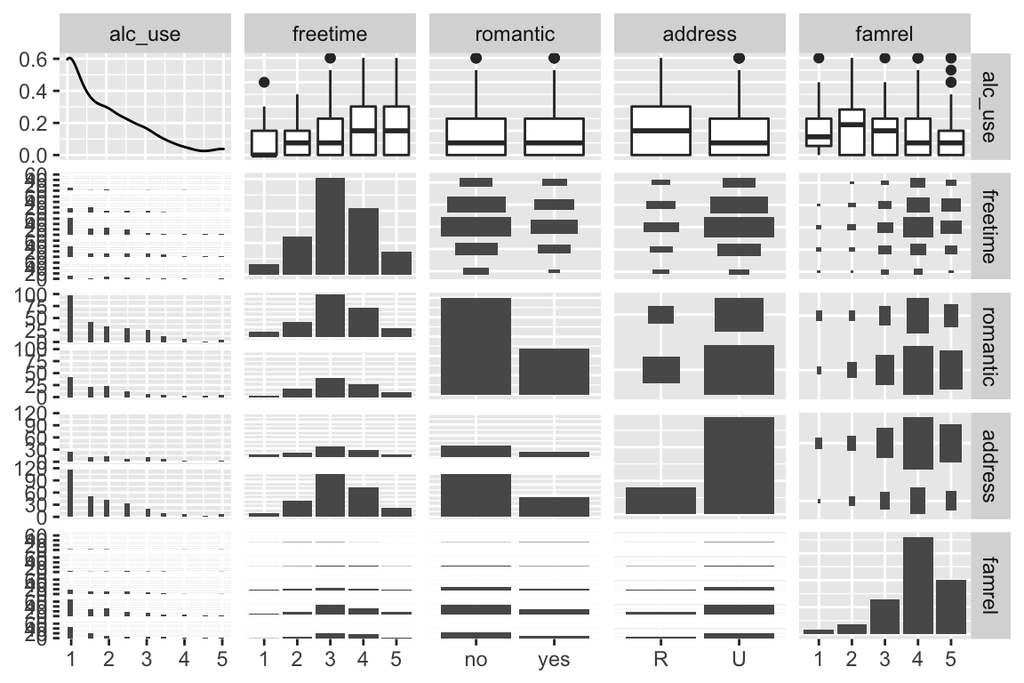

```r
library(ggplot2)
library(GGally)
cor_data = alc_data[, c("alc_use", interesting_cols)]
#cast as factors so that they are visualised correctly
cor_data$freetime = as.factor(cor_data$freetime)
cor_data$romantic = as.factor(cor_data$romantic)
cor_data$address = as.factor(cor_data$address)
cor_data$famrel = as.factor(cor_data$famrel)
ggpairs(cor_data)
```

I have non-significant support for the hypotheses made above for all but “romantic” relationship. So it seems that relationship status has absolutely no correlation with the alcohol consumption.

Lets study the problem with logistic regression model.

```r
cor_data$freetime = as.numeric(cor_data$freetime)
cor_data$famrel = as.numeric(cor_data$famrel)
glm_data = cbind("high_use"=alc_data$high_use, cor_data[,interesting_cols])
logreg_fit = glm(high_use ~ ., data = glm_data, family="binomial")
```

For the continuous (ordinal features, that is, freetime and famrel) we can exponentiate, to get the odds ratios:

```r
exp(logreg_fit$coefficients[c("freetime", "famrel")])
```

```
##  freetime    famrel
## 1.5537064 0.6932053
```

So free time, being having a unit more of free time, increases the chances of high use of alcohol 1.5 times higher. On the other hand, having a unit increase in family relations, that is having better family relationships, makes decreases the chances of high use of alcohol by 1.45 times (because 0.69, which is 1 / 1.45).

The same happens with the discrete features, but we need to be careful with the interpretation of unit addition.

```r
exp(logreg_fit$coefficients[c("romanticyes", "addressU")])
```

```
## romanticyes    addressU
##   0.7760629   0.5883402
```

Here it seems that romantic relation and address in urban area seem to have negative effect on the high use of alcohol, just like predicted.

The confidence intervals can be fetched with the following command

```r
exp(confint(logreg_fit))
```

```
##                 2.5 %    97.5 %
## (Intercept) 0.1940075 2.3182620
## freetime    1.2228777 1.9926747
## romanticyes 0.4657483 1.2726638
## addressU    0.3451026 1.0102441
## famrel      0.5378060 0.8906739
```

So, the only confidence intervals not covering the “no effect” value of 1 are freetime and famrel, meaning that they provide more statistical evidence that indeed more freetime is associated with higher use and better family relationships are related with not high use.

Lets create the 2x2 cross-tabulation, also known as confusion matrix,

```r
cmat = table(high_use = glm_data$high_use, prediction = (predict(logreg_fit, newdata=glm_data, type="response") > 0.5))
print(cmat)
```

```
##         prediction
## high_use FALSE TRUE
##    FALSE   248   11
##    TRUE    104    7
```

and compute the training error:

```r
#training error:
sum(c(cmat[1,2], cmat[2,1])) / sum(cmat)
```

```
## [1] 0.3108108
```

```r
#random guessing:
print(mean(glm_data$high_use))
```

```
## [1] 0.3
```

The model misclassifices 31% of the training cases. So the interpretation is that on average 3 out of 10 samples is misclassified. With random guessing one gets, on average, as low errors as predicting the majority class. That is, the random guessing is actually better, because it gets an error as low as 30%. So this means that the model fit to the data is actually very poor, and the interpretation should not be trusted.

(more chapters to be added similarly as we proceed with the course!)